# Multiple Linear Regression Practice

## Introduction

This analysis uses the “two-lines” multiple regression model to describe the price of a house according to the size of the living area and whether or not the house has a fireplace, using a subset of the `SaratogaHouses` dataset.

## Data Preparation

First, we load the data and filter it for newly constructed homes with three bedrooms.

```r
data(SaratogaHouses)

# Filter for 3 bedrooms and new construction
SH2 <- filter(SaratogaHouses, bedrooms == 3, newConstruction == "Yes")

# Verify the data
head(SH2)
```

```
##    price lotSize age landValue livingArea pctCollege bedrooms fireplaces
## 1 148635    0.32   1      6200       1576         39        3          0
## 2 208767    0.50   0     32000       1662         52        3          0
## 3 192000    0.82   0      5000       1880         44        3          1
## 4 158000    0.52   0      4400       2098         44        3          0
## 5 180377    0.35   1     37000       1820         64        3          1
## 6 205980    0.14   1     45200       1983         64        3          1
##   bathrooms rooms heating fuel             sewer waterfront newConstruction
## 1       2.5     7 hot air  gas            septic         No             Yes
## 2       2.0     7 hot air  gas public/commercial         No             Yes
## 3       2.5     9 hot air  gas            septic         No             Yes
## 4       2.0     7 hot air  gas            septic         No             Yes
## 5       2.5     6 hot air  gas public/commercial         No             Yes
## 6       2.5     5 hot air  gas public/commercial         No             Yes
##   centralAir
## 1        Yes
## 2        Yes
## 3        Yes
## 4        Yes
## 5         No
## 6        Yes
```

## Two-Lines Regression Model

We fit a multiple regression model with an interaction term between `livingArea` and `fireplaces`. This allows for different slopes (two lines) for homes with and without fireplaces.

The model is:
$$Y_i = \beta_0 + \beta_1
X_{1i} + \beta_2 X_{2i} + \beta_3 X_{1i}X_{2i} + \epsilon_i$$
where: * $Y_i$ is Price * $X_{1i}$ is Living Area * $X_{2i}$ is Fireplaces (0 or 1)

```r
# Fit the regression model
# filling in the blanks: lm(price ~ livingArea + fireplaces + livingArea:fireplaces, data=SH2)
sh2.lm <- lm(price ~ livingArea + fireplaces + livingArea:fireplaces, data=SH2)

# Show the summary results
summary(sh2.lm)
```

```
##
## Call:
## lm(formula = price ~ livingArea + fireplaces + livingArea:fireplaces,
##     data = SH2)
##
## Residuals:
##    Min     1Q Median     3Q    Max
## -45981 -17649  -1536  11214  55037
##
## Coefficients:
##                         Estimate Std. Error t value Pr(>|t|)
## (Intercept)            -12289.69   59660.13  -0.206   0.8392
## livingArea                103.08      32.43   3.178   0.0055 **
## fireplaces            -116722.52   74518.95  -1.566   0.1357
## livingArea:fireplaces      74.75      37.94   1.970   0.0654 .
## ---
## Signif. codes:  0 '***' 0.001 '**' 0.01 '*' 0.05 '.' 0.1 ' ' 1
##
## Residual standard error: 27710 on 17 degrees of freedom
## Multiple R-squared:  0.8955, Adjusted R-squared:  0.8771
## F-statistic: 48.57 on 3 and 17 DF,  p-value: 1.5e-08
```

## Interpretation

From the summary above, we can extract the coefficients to interpret the effect of living area and fireplaces.

- **$\beta_1$ (livingArea)**: The change in the average price of a home *without* a fireplace as the living area increases by 1 additional square foot.
- **$\beta_2$ (fireplaces)**: The difference in the average price of a home with a fireplace as compared to a home without a fireplace for homes with zero square feet of living area (intercept adjustment).
- **$\beta_3$ (livingArea:fireplaces)**: The change in the effect of 1 additional square foot in the living area on the average price of homes with a fireplace as compared to homes without a fireplace (slope adjustment).

## Hypothesis Testing

We can check the p-values for the specific coefficients.

### Test for Fireplace Effect (Intercept Difference)

$H_0: \beta_2 = 0$ vs $H_a: \beta_2 \neq 0$

```r
# P-value for fireplaces coefficient
p_val_beta2 <- summary(sh2.lm)$coefficients["fireplaces", "Pr(>|t|)"]
p_val_beta2
```

```
## [1] 0.1356915
```

### Test for Interaction Effect (Slope Difference)

$H_0: \beta_3 = 0$ vs $H_a: \beta_3 \neq 0$

```r
# P-value for interaction term
p_val_beta3 <- summary(sh2.lm)$coefficients["livingArea:fireplaces", "Pr(>|t|)"]
p_val_beta3
```

```
## [1] 0.06535363
```

## Visualization

We visualize the model by plotting the data points and adding the two regression lines.

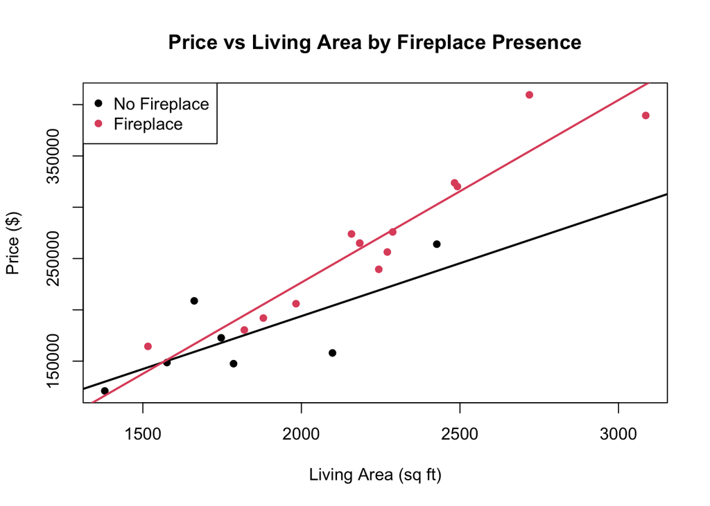

```r
# Plot the data
plot(price ~ livingArea, data=SH2, col=as.factor(fireplaces), pch=16,
     main="Price vs Living Area by Fireplace Presence",
     xlab="Living Area (sq ft)", ylab="Price ($)")

# Add legend
legend("topleft", legend=c("No Fireplace", "Fireplace"), col=1:2, pch=16)

# Extract coefficients
b <- coef(sh2.lm)

# Line for No Fireplace (fireplaces = 0): y = b0 + b1*x
abline(a = b[1], b = b["livingArea"], col=1, lwd=2)

# Line for Fireplace (fireplaces = 1): y = (b0 + b2) + (b1 + b3)*x
# Intercept is b[1] + b["fireplaces"]
# Slope is b["livingArea"] + b["livingArea:fireplaces"]
abline(a = b[1] + b["fireplaces"],
       b = b["livingArea"] + b["livingArea:fireplaces"],
       col=2, lwd=2)
```

## Diagnostics

We check the appropriateness of the model using diagnostic plots.

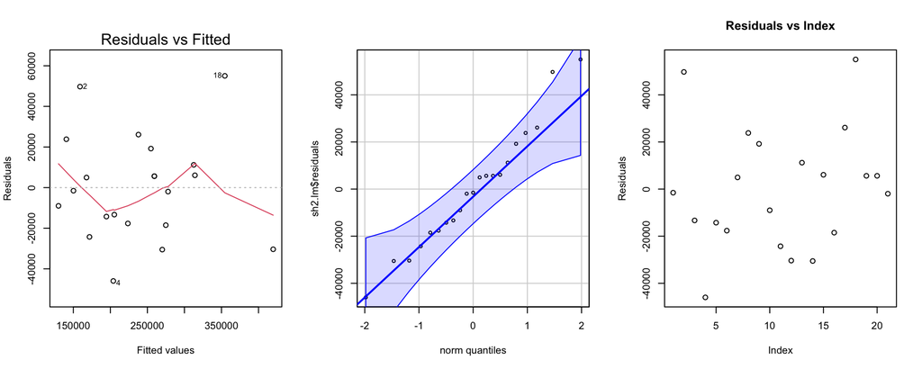

```r
par(mfrow=c(1,3))

# 1. Residuals vs Fitted
plot(sh2.lm, which=1)

# 2. QQ Plot of Residuals
qqPlot(sh2.lm$residuals, id=FALSE)

# 3. Plot of Residuals (Index plot)
plot(sh2.lm$residuals, main="Residuals vs Index", ylab="Residuals")
```

```r
par(mfrow=c(1,1)) # Reset layout
```

### Inspecting Potential Outliers

```r
# Inspecting specific rows mentioned in the problem description
outliers <- SH2[c(1, 2, 3, 4, 15, 16, 17, 18, 24, 25, 26), ]
outliers
```

```
##       price lotSize age landValue livingArea pctCollege bedrooms fireplaces
## 1    148635    0.32   1      6200       1576         39        3          0
## 2    208767    0.50   0     32000       1662         52        3          0
## 3    192000    0.82   0      5000       1880         44        3          1
## 4    158000    0.52   0      4400       2098         44        3          0
## 15   320210    0.81   1    108900       2492         40        3          1
## 16   256350    0.35   1    108900       2271         40        3          1
## 17   264000    0.21   1     32000       2427         40        3          0
## 18   409550    0.69   1     83500       2719         61        3          1
## NA       NA      NA  NA        NA         NA         NA       NA         NA
## NA.1     NA      NA  NA        NA         NA         NA       NA         NA
## NA.2     NA      NA  NA        NA         NA         NA       NA         NA
##      bathrooms rooms heating fuel             sewer waterfront newConstruction
## 1          2.5     7 hot air  gas            septic         No             Yes
## 2          2.0     7 hot air  gas public/commercial         No             Yes
## 3          2.5     9 hot air  gas            septic         No             Yes
## 4          2.0     7 hot air  gas            septic         No             Yes
## 15         2.5     9 hot air  gas public/commercial         No             Yes
## 16         2.5     6 hot air  gas public/commercial         No             Yes
## 17         2.5     9 hot air  gas public/commercial         No             Yes
## 18         2.0     9 hot air  gas            septic         No             Yes
## NA          NA    NA    <NA> <NA>              <NA>       <NA>            <NA>
## NA.1        NA    NA    <NA> <NA>              <NA>       <NA>            <NA>
## NA.2        NA    NA    <NA> <NA>              <NA>       <NA>            <NA>
##      centralAir
## 1           Yes
## 2           Yes
## 3           Yes
## 4           Yes
## 15           No
## 16           No
## 17           No
## 18          Yes
## NA         <NA>
## NA.1       <NA>
## NA.2       <NA>
```

## Quadratic Regression Practice

This section uses the `airquality` dataset to model Temperature as a quadratic function of Month.

### Model Fitting

The model is: $Y_i = \beta_0 + \beta_1 X_i + \beta_2 X_i^2 + \epsilon_i$ where $Y_i$ is Temperature and $X_i$ is Month.

```r
data(airquality)

# Fit the quadratic model
aq.lm <- lm(Temp ~ Month + I(Month^2), data=airquality)

# Show summary
summary(aq.lm)
```

```
##
## Call:
## lm(formula = Temp ~ Month + I(Month^2), data = airquality)
##
## Residuals:
##      Min       1Q   Median       3Q      Max
## -13.8311  -4.4446  -0.4446   3.5972  16.1689
##
## Coefficients:
##             Estimate Std. Error t value Pr(>|t|)
## (Intercept) -95.7256    15.2412  -6.281 3.46e-09 ***
## Month        48.7183     4.4889  10.853  < 2e-16 ***
## I(Month^2)   -3.2828     0.3199 -10.263  < 2e-16 ***
## ---
## Signif. codes:  0 '***' 0.001 '**' 0.01 '*' 0.05 '.' 0.1 ' ' 1
##
## Residual standard error: 6.624 on 150 degrees of freedom
## Multiple R-squared:  0.5166, Adjusted R-squared:  0.5102
## F-statistic: 80.16 on 2 and 150 DF,  p-value: < 2.2e-16
```

### Diagnostics

We check the appropriateness of the model.

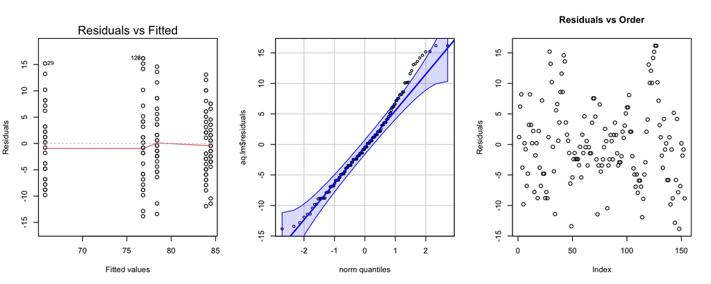

```r
par(mfrow=c(1,3))
plot(aq.lm, which=1)
qqPlot(aq.lm$residuals, id=FALSE)
plot(aq.lm$residuals, main="Residuals vs Order", ylab="Residuals")
```

```r
par(mfrow=c(1,1))
```

### Prediction

Predicting the average high temperature for July 4th (Month = 7.129032).

```r
# Prediction for July 4th
july4_month <- 7 + 4/31
pred_july4 <- predict(aq.lm, newdata=data.frame(Month=july4_month))
pred_july4
```

```
##        1
## 84.74588
```

### Visualization

Visualizing the quadratic fit and the prediction.

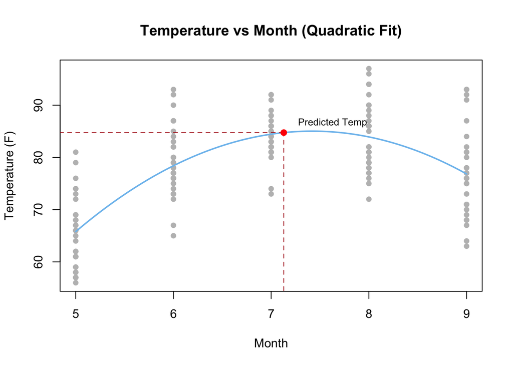

```r
# Plot the data
plot(Temp ~ Month, data=airquality, pch=16, col="gray",
     main="Temperature vs Month (Quadratic Fit)",
     xlab="Month", ylab="Temperature (F)")

# Add the quadratic curve
b <- coef(aq.lm)
curve(b[1] + b[2]*x + b[3]*x^2, add=TRUE, col="skyblue2", lwd=2)

# Add the prediction lines and point
lines(c(july4_month, july4_month), c(0, pred_july4), lty=2, col="firebrick")
lines(c(0, july4_month), c(pred_july4, pred_july4), lty=2, col="firebrick")
points(july4_month, pred_july4, cex=1.2, col="red", pch=16)
text(july4_month + 0.5, pred_july4, "Predicted Temp", cex=0.8, pos=3)
```

### Vertex Calculation

Finding the warmest month (vertex of the parabola). Vertex x-coordinate = $-b_1 / (2b_2)$.

```r
# Calculate vertex
vertex_x <- -b[2] / (2 * b[3])
vertex_y <- b[1] + b[2]*vertex_x + b[3]*vertex_x^2

cat("Vertex Month:", vertex_x, "\n")
```

```
## Vertex Month: 7.420204
```

```r
cat("Max Temperature:", vertex_y, "\n")
```

```
## Max Temperature: 85.0242
```

## RailTrail Regression Practice

This section uses the `RailTrail` dataset to model the volume of users as a function of high temperature and rain.

### Data Preparation

We create a new column `rain` which is 1 if `precip > 0` and 0 otherwise.

```r
data(RailTrail)

# Create rain column
RailTrail <- mutate(RailTrail, rain = ifelse(precip > 0, 1, 0))

# Verify the new column
head(RailTrail)
```

```
##   hightemp lowtemp avgtemp spring summer fall cloudcover precip volume weekday
## 1       83      50    66.5      0      1    0        7.6   0.00    501    TRUE
## 2       73      49    61.0      0      1    0        6.3   0.29    419    TRUE
## 3       74      52    63.0      1      0    0        7.5   0.32    397    TRUE
## 4       95      61    78.0      0      1    0        2.6   0.00    385   FALSE
## 5       44      52    48.0      1      0    0       10.0   0.14    200    TRUE
## 6       69      54    61.5      1      0    0        6.6   0.02    375    TRUE
##   dayType rain
## 1 weekday    0
## 2 weekday    1
## 3 weekday    1
## 4 weekend    0
## 5 weekday    1
## 6 weekday    1
```

### Initial Visualization

We visualize the relationship between volume and high temperature, colored by rain.

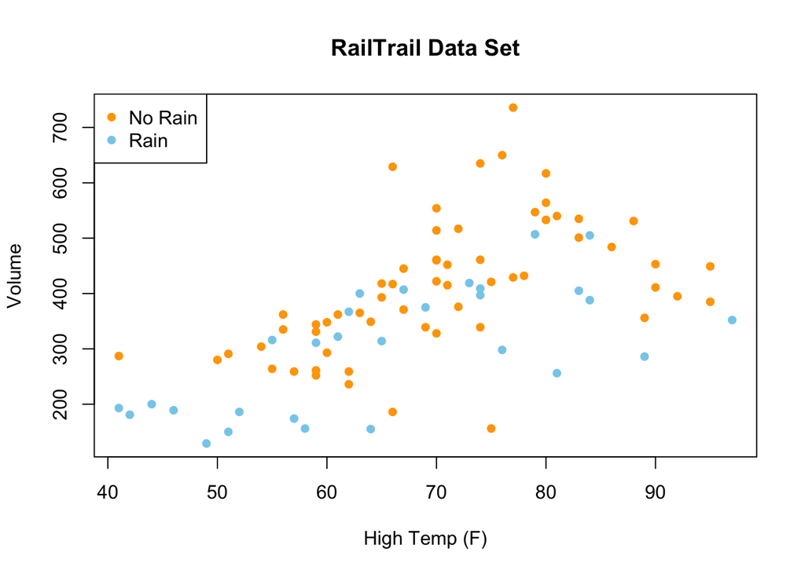

```r
palette(c("orange","skyblue"))
plot(volume ~ hightemp, data=RailTrail, col=as.factor(rain), pch=16,
     main="RailTrail Data Set", xlab="High Temp (F)", ylab="Volume")
legend("topleft", legend=c("No Rain", "Rain"), col=palette(), pch=16)
```

### Interaction Model (Two-Lines)

We first fit a model allowing for interaction between high temperature and rain.

$$Y_i = \beta_0 + \beta_1 X_{1i} +
\beta_2 X_{2i} + \beta_3 X_{1i}X_{2i} + \epsilon_i$$

```r
rail_interaction.lm <- lm(volume ~ hightemp + rain + hightemp:rain, data=RailTrail)
summary(rail_interaction.lm)
```

```
##
## Call:
## lm(formula = volume ~ hightemp + rain + hightemp:rain, data = RailTrail)
##
## Residuals:
##      Min       1Q   Median       3Q      Max
## -278.557  -64.933   -0.977   52.718  290.913
##
## Coefficients:
##               Estimate Std. Error t value Pr(>|t|)
## (Intercept)    39.6764    76.4290   0.519    0.605
## hightemp        5.2651     1.0706   4.918 4.15e-06 ***
## rain          -67.6236   112.7843  -0.600    0.550
## hightemp:rain  -0.2322     1.6350  -0.142    0.887
## ---
## Signif. codes:  0 '***' 0.001 '**' 0.01 '*' 0.05 '.' 0.1 ' ' 1
##
## Residual standard error: 97.82 on 86 degrees of freedom
## Multiple R-squared:  0.4309, Adjusted R-squared:  0.411
## F-statistic:  21.7 on 3 and 86 DF,  p-value: 1.479e-10
```

### Reduced Model (Parallel Slopes)

Since the interaction term is not significant, we fit a reduced model without the interaction term.

$$Y_i = \beta_0 + \beta_1 X_{1i} +
\beta_2 X_{2i} + \epsilon_i$$

```r
# Fit the reduced model
rail.lm <- lm(volume ~ hightemp + rain, data=RailTrail)
summary(rail.lm)
```

```
##
## Call:
## lm(formula = volume ~ hightemp + rain, data = RailTrail)
##
## Residuals:
##     Min      1Q  Median      3Q     Max
## -278.10  -66.12   -0.37   52.60  291.57
##
## Coefficients:
##             Estimate Std. Error t value Pr(>|t|)
## (Intercept)  46.6863    58.0175   0.805 0.423191
## hightemp      5.1655     0.8046   6.420 6.94e-09 ***
## rain        -83.3190    22.2971  -3.737 0.000333 ***
## ---
## Signif. codes:  0 '***' 0.001 '**' 0.01 '*' 0.05 '.' 0.1 ' ' 1
##
## Residual standard error: 97.27 on 87 degrees of freedom
## Multiple R-squared:  0.4308, Adjusted R-squared:  0.4177
## F-statistic: 32.92 on 2 and 87 DF,  p-value: 2.268e-11
```

### Visualization of Reduced Model

We plot the parallel regression lines.

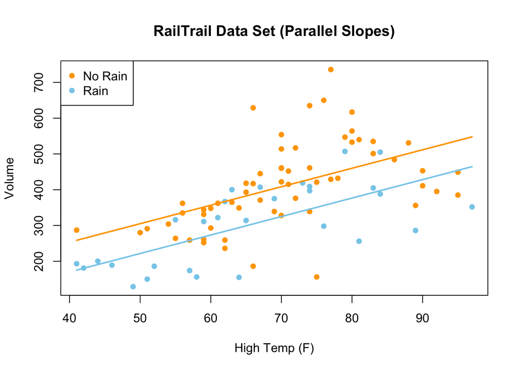

```r
palette(c("orange","skyblue"))
plot(volume ~ hightemp, data=RailTrail, col=as.factor(rain), pch=16,
     main="RailTrail Data Set (Parallel Slopes)", xlab="High Temp (F)", ylab="Volume")
legend("topleft", legend=c("No Rain", "Rain"), col=palette(), pch=16)

# Extract coefficients
b <- coef(rail.lm)

# Line for No Rain (rain=0): y = b0 + b1*x
curve(b[1] + b["hightemp"]*x, add=TRUE, col="orange", lwd=2)

# Line for Rain (rain=1): y = (b0 + b2) + b1*x
curve((b[1] + b["rain"]) + b["hightemp"]*x, add=TRUE, col="skyblue", lwd=2)
```

### Diagnostics

We check the appropriateness of the model using diagnostic plots.

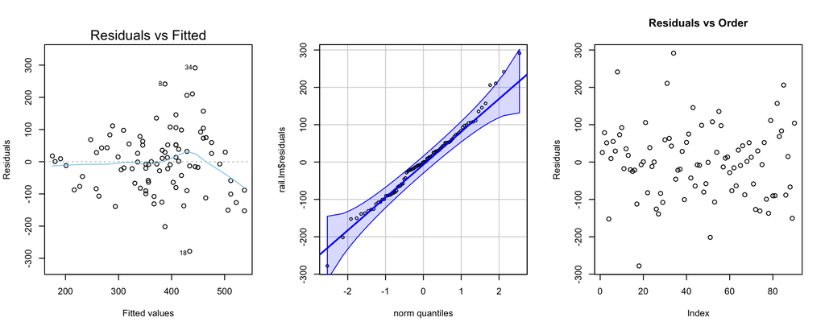

```r
par(mfrow=c(1,3))
plot(rail.lm, which=1)
qqPlot(rail.lm$residuals, id=FALSE)
plot(rail.lm$residuals, main="Residuals vs Order", ylab="Residuals")
```

```r
par(mfrow=c(1,1))
```